# Assignment 9: Final Shopify Store Reflection Report

Atelier North — Final Reflection and CPP Farm Store Application

Author

Brian

Published

August 10, 2026

## 2. Final Store Evidence

### Homepage

Full-width green hero banner, “Atelier North” wordmark, brand description, and top navigation with Home, Catalog, Contact, and three category links.

[figure not shown]

Homepage

### Product catalog / product page

The full Catalog page lists all 9 products in a filterable, sortable grid.

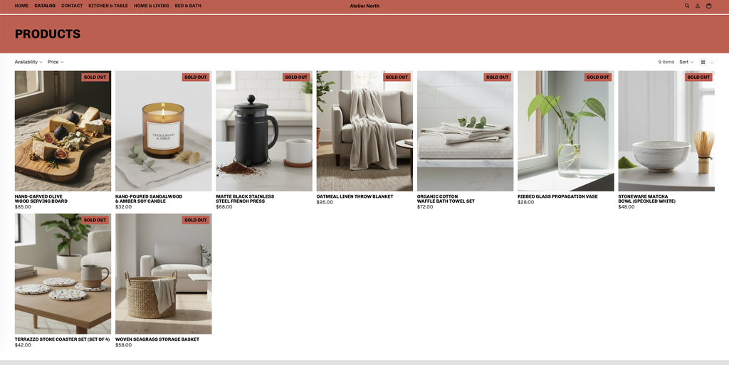

Catalog page

Individual product pages include large lifestyle photography, price, a quantity selector, and benefit-driven descriptive copy.

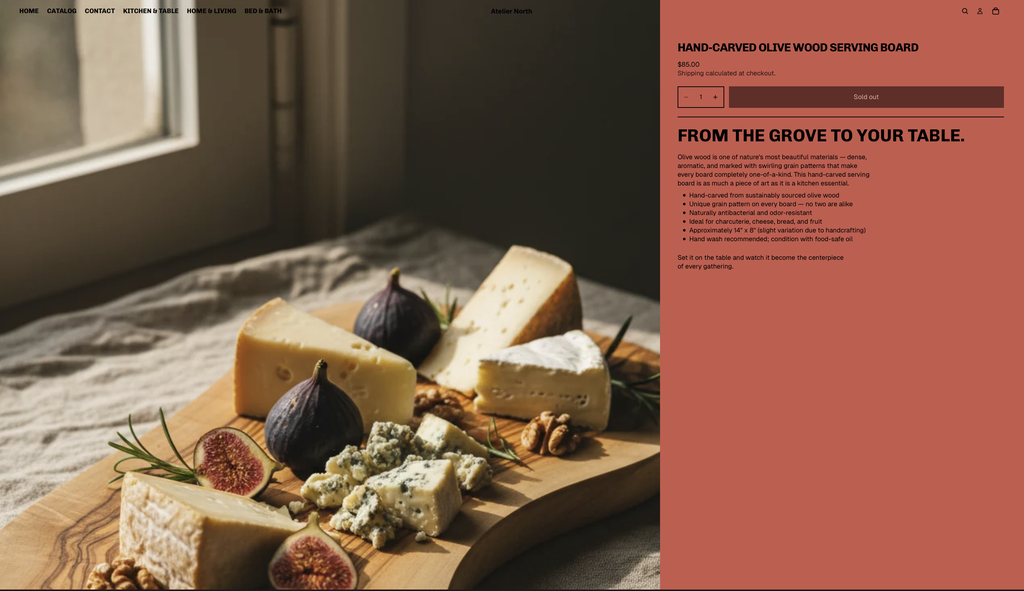

Product page — Hand-Carved Olive Wood Serving Board

[figure not shown]

Product page — Organic Cotton Waffle Bath Towel Set

### Collection page

The Home & Living collection page correctly filters the catalog down to its 3 relevant items.

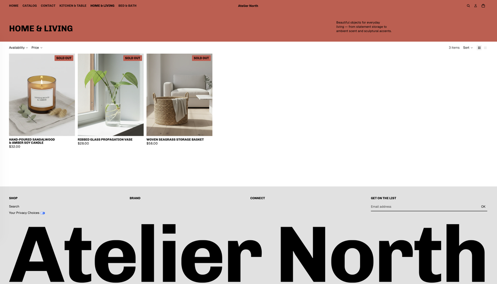

Home & Living collection page

### Navigation menu

The top nav is consistent across every page, exposing Home, Catalog, Contact, and all three product categories.

[figure not shown]

Homepage — navigation menu visible

### Policy / contact information

The Contact page includes a standard inquiry form (Name, Email, Phone, Comment) plus a footer with shop links and newsletter signup.

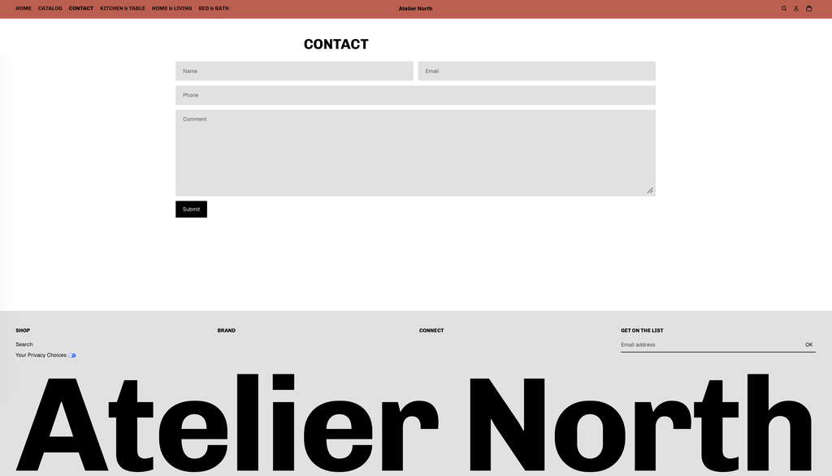

Contact page

### GA4 / Shopify analytics evidence

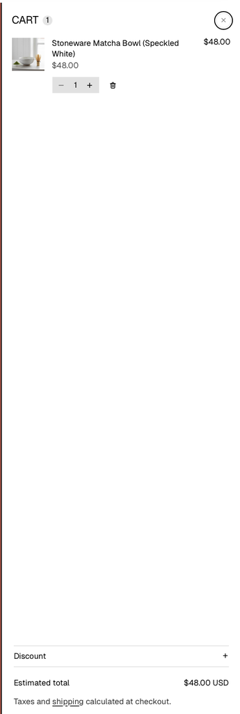

Cart drawer showing an item successfully added

The Shopify Analytics dashboard, reviewed as part of Assignment 8, shows the expected zero-state metrics for an unlaunched store.

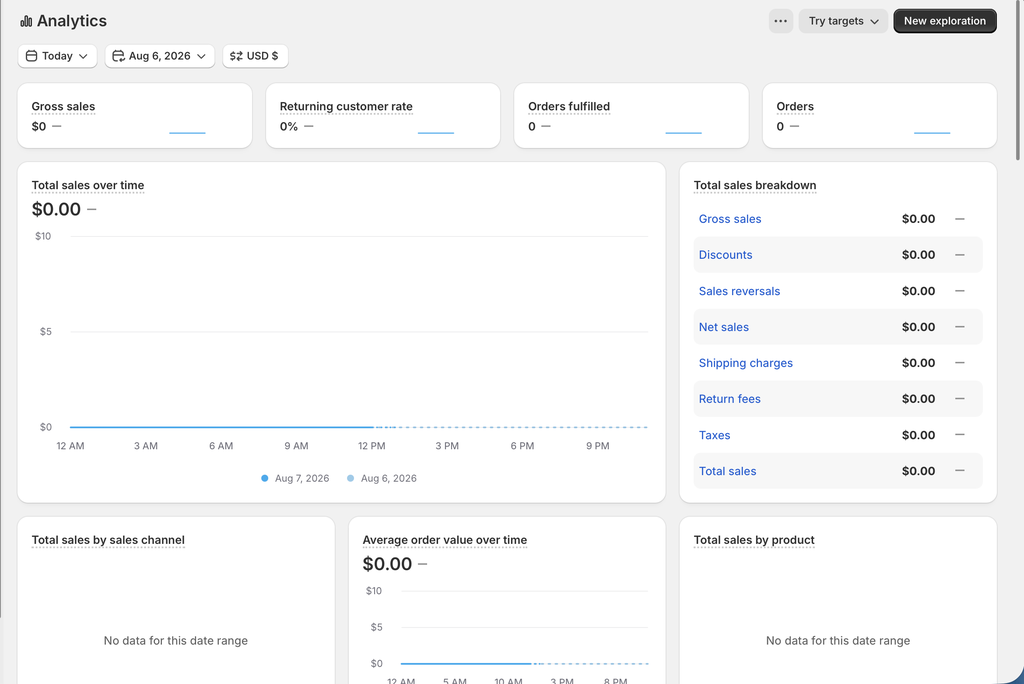

Shopify Analytics dashboard

## 3. Retail Technology Reflection

Building Atelier North taught me that Shopify functions as a full retail operating system, not just a storefront builder. Setting up products, collections, navigation, and policies made clear how much of the “retail” work — merchandising rules, inventory status, checkout logic — is handled declaratively through the platform rather than through custom code. I also learned that Shopify’s default behaviors (like inventory-driven “Sold out” states) directly shape the customer experience, and that platform configuration choices are retail decisions, not just technical ones. Testing the customer journey end to end showed me how tightly the platform couples storefront presentation with backend inventory and cart logic, and how a single misconfiguration (like the sold-out/cart mismatch I found in Assignment 8) can break the entire funnel even when every individual page looks polished.

## 4. Merchandising Reflection

Working through product catalog setup, collections, and navigation taught me that merchandising on Shopify is really an exercise in information architecture. Deciding which three categories to expose in the nav, how to group products into collections, and how to write product copy that sells a narrative rather than just specs all directly affected how easy the store was to browse. I learned that collection filtering (by availability and price) is a merchandising tool as much as a technical feature — it lets a shopper self-select into the products relevant to them. I also learned that storefront design and merchandising can’t be evaluated separately from inventory accuracy: a beautifully merchandised collection page still fails the customer if every item is unavailable, which was the central issue I uncovered in my customer journey testing.

## 5. Analytics Reflection

Reviewing the built-in Shopify Analytics dashboard showed me what a retailer sees by default — gross sales, returning customer rate, orders fulfilled — and how those metrics stay at zero without real traffic and transactions. This made concrete why GA4 integration matters: GA4 is what would let me see behavior *before* a purchase decision (sessions, page views, funnel drop-off by stage) rather than just post-purchase totals. Connecting this to the CPP Farm Store dashboard project, where I was responsible for designing dashboard sections to evaluate omnichannel and ecommerce campaign performance, reinforced that analytics only becomes useful once it’s organized around specific business questions (channel performance, campaign ROI, customer behavior) rather than just displayed as raw metrics. Testing my own store’s customer journey was a useful complement to that dashboard work — it showed me firsthand what a broken step in the funnel (like the sold-out inconsistency) looks like from the customer side, which is exactly the kind of drop-off a GA4 funnel report would need to surface.

## 6. CPP Farm Store Application

1. **Funnel and drop-off visibility.** The customer journey testing method I used on Atelier North — walking homepage → collection → product → cart → checkout and logging where the experience breaks — is directly transferable to CPP Farm Store. A GA4 funnel exploration could quantify where real customers abandon the path, the same way I manually caught the sold-out/cart mismatch on my own store.
2. **Inventory and merchandising accuracy as a conversion lever.** My experience with sold-out statuses blocking checkout shows CPP Farm Store that inventory data quality is itself a conversion driver — a GA4/Shopify dashboard should flag high-traffic products that are unavailable, since these are lost-sale opportunities.
3. **Channel-level dashboard design.** The dashboard sections I designed for the CPP Farm Store GP6 project (evaluating omnichannel and ecommerce campaign performance) apply the same principle I practiced on Atelier North’s Shopify Analytics page: organize metrics (sessions, conversion rate, average order value) by the questions the business actually needs answered — in CPP Farm Store’s case, comparing in-store/omnichannel performance against pure ecommerce channel performance.

## 7. Final Self-Assessment

I’m proud of the visual and content consistency across Atelier North — the color palette, typography, and benefit-driven product copy give the store a cohesive, premium feel from the homepage through individual product pages. With more time, I would fix the inventory configuration so every product supports a full end-to-end checkout test, and I would generate real test traffic so the Shopify Analytics and GA4 dashboards showed actual session, conversion, and sales-by-product data instead of a zero-state — that would let me evaluate real customer behavior rather than just the static storefront design.

## Appendix

- **GitHub Repository:** https://github.com/brianvuong1/retail-marketing
- **Store URL:** https://10b3ys-0m.myshopify.com